# Session 2: Homework 1

Group 5

2020-09-06

```r
knitr::opts_chunk$set(
  message = FALSE,
  warning = FALSE,
  tidy=FALSE,     # display code as typed
  size="small")   # slightly smaller font for code
options(digits = 3)

# default figure size
knitr::opts_chunk$set(
  fig.width=6.75,
  fig.height=6.75,
  fig.align = "center"
)

options(scipen=999)
```

# 1 Where Do People Drink The Most Beer, Wine And Spirits?

Back in 2014, [fivethiryeight.com](https://fivethirtyeight.com/features/dear-mona-followup-where-do-people-drink-the-most-beer-wine-and-spirits/) published an article on alchohol consumption in different countries. The data `drinks` is available as part of the `fivethirtyeight` package. Make sure you have installed the `fivethirtyeight` package before proceeding.

```r
library(fivethirtyeight)
data(drinks)


# or download directly
# alcohol_direct <- read_csv("https://raw.githubusercontent.com/fivethirtyeight/data/master/alcohol-consumption/drinks.csv")
```

What are the variable types? Any missing values we should worry about?

```r
str(drinks)
```

```
## tibble [193 x 5] (S3: tbl_df/tbl/data.frame)
##  $ country                     : chr [1:193] "Afghanistan" "Albania" "Algeria" "Andorra" ...
##  $ beer_servings               : int [1:193] 0 89 25 245 217 102 193 21 261 279 ...
##  $ spirit_servings             : int [1:193] 0 132 0 138 57 128 25 179 72 75 ...
##  $ wine_servings               : int [1:193] 0 54 14 312 45 45 221 11 212 191 ...
##  $ total_litres_of_pure_alcohol: num [1:193] 0 4.9 0.7 12.4 5.9 4.9 8.3 3.8 10.4 9.7 ...
##  - attr(*, "spec")=
##   .. cols(
##   ..   country = col_character(),
##   ..   beer_servings = col_integer(),
##   ..   spirit_servings = col_integer(),
##   ..   wine_servings = col_integer(),
##   ..   total_litres_of_pure_alcohol = col_double()
##   .. )
```

```r
# checking for missing variables
head(drinks)
```

```
## # A tibble: 6 x 5
##   country      beer_servings spirit_servings wine_servings total_litres_of_pure~
##   <chr>                <int>           <int>         <int>                 <dbl>
## 1 Afghanistan              0               0             0                   0
## 2 Albania                 89             132            54                   4.9
## 3 Algeria                 25               0            14                   0.7
## 4 Andorra                245             138           312                  12.4
## 5 Angola                 217              57            45                   5.9
## 6 Antigua & B~           102             128            45                   4.9
```

```r
skim(drinks)[,c("skim_variable","n_missing")]
```

```
## # A tibble: 5 x 2
##   skim_variable                n_missing
##   <chr>                            <int>
## 1 country                              0
## 2 beer_servings                        0
## 3 spirit_servings                      0
## 4 wine_servings                        0
## 5 total_litres_of_pure_alcohol         0
```

As seen from above, the variable types are character for country, integer for beer, spirit and wine servings, and double for total litres of pure alcohol. There are no missing values in the dataset, though there are countries without zero-valued data such as Afghanistan and Bangladesh.

Make a plot that shows the top 25 beer consuming countries

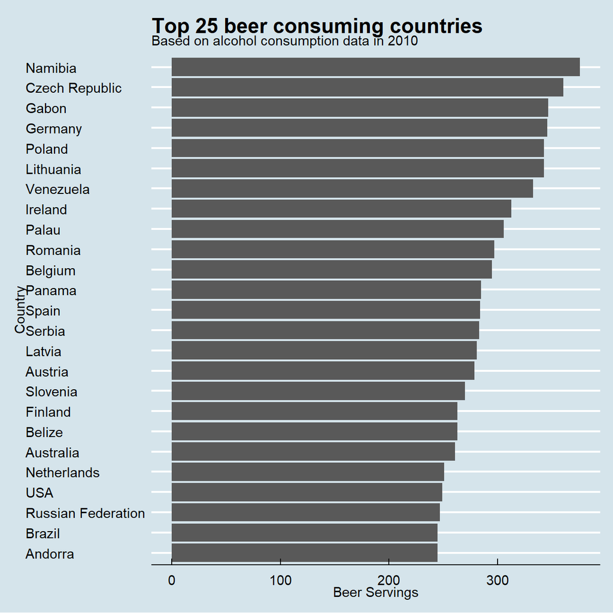

```r
# YOUR CODE GOES HERE
top25 <- drinks %>% top_n(25,beer_servings)
ggplot(top25, aes(x = beer_servings, y= reorder(country,beer_servings))) +
  geom_col() +
  labs(
    title="Top 25 beer consuming countries",
    subtitle="Based on alcohol consumption data in 2010",
    x="Beer Servings",
    y="Country"
  ) +
  theme_economist()
```

Make a plot that shows the top 25 wine consuming countries

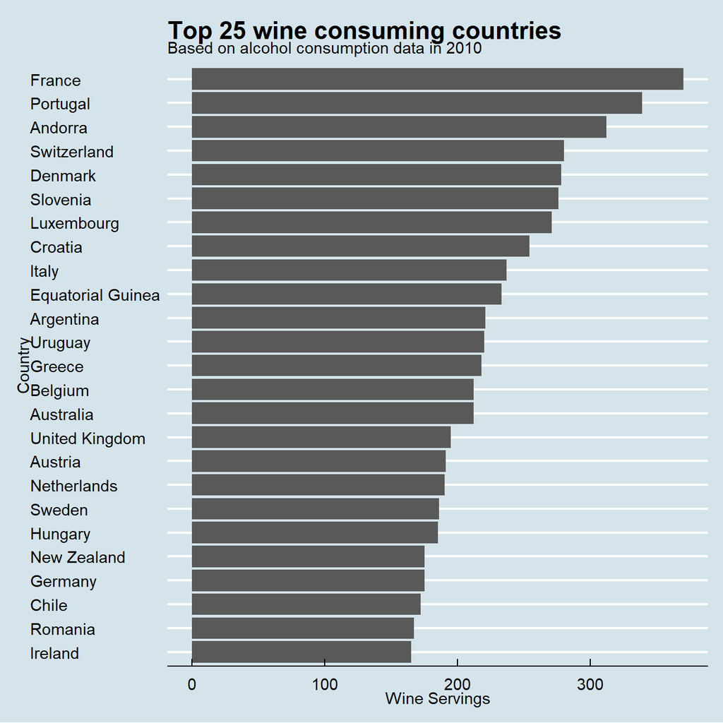

```r
topwine <- drinks %>% top_n(25,wine_servings)
ggplot(topwine, aes(x = wine_servings, y= reorder(country,wine_servings))) +
  geom_col() +
  labs(
    title="Top 25 wine consuming countries",
    subtitle="Based on alcohol consumption data in 2010",
    x="Wine Servings",
    y="Country"
  ) +
  theme_economist()
```

Finally, make a plot that shows the top 25 spirit consuming countries

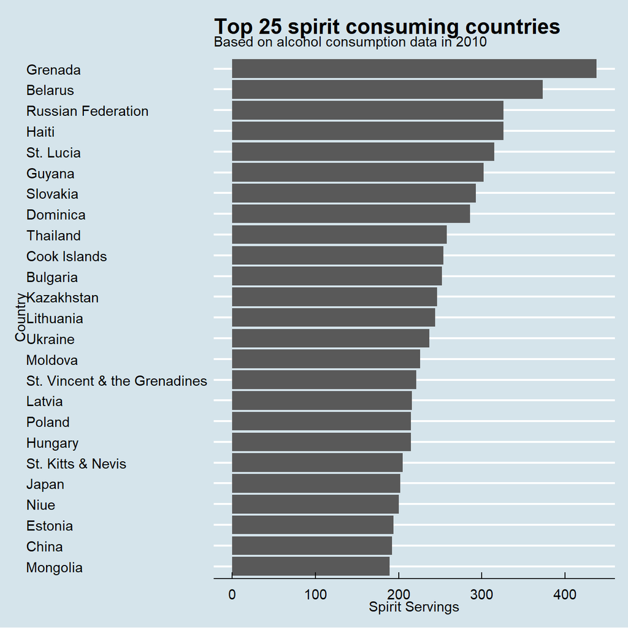

```r
# YOUR CODE GOES HERE
topspirit <- drinks %>% top_n(25,spirit_servings)
ggplot(topspirit, aes(x = spirit_servings, y= reorder(country,spirit_servings))) +
  geom_col() +
  labs(
    title="Top 25 spirit consuming countries",
    subtitle="Based on alcohol consumption data in 2010",
    x="Spirit Servings",
    y="Country"
  ) +
  theme_economist()
```

What can you infer from these plots? Don’t just explain what’s in the graph, but speculate or tell a short story (1-2 paragraphs max).

> TYPE YOUR ANSWER AFTER (AND OUTSIDE!) THIS BLOCKQUOTE.

Notably, one-off events taking place in 2010 with high alcohol consumption associated to them could have also distorted these results. For instance, the 2010 World Cup took place in South Africa, potentially impacting the high alcohol consumption in neighboring Namibia. Similarly, countries such as Spain, the Netherlands, Brazil and Germany made it to the final stages of the tournament - and we speculate that the longer a country proceeds in such sporting events, the higher the beer consumption. Lastly, the limitations of the charts above must be noted. In fact, the data displayed dates back to 2010 and consequently it is fairly outdated and might not paint an accurate picture of the current alcohol consumption trends, which over 10 years could have changed dramatically.

# 2 Analysis of movies- IMDB dataset

We will look at a subset sample of movies, taken from the [Kaggle IMDB 5000 movie dataset](https://www.kaggle.com/carolzhangdc/imdb-5000-movie-dataset)

```r
movies <- read_csv(here::here("data", "movies.csv"))
glimpse(movies)
```

```
## Rows: 2,961
## Columns: 11
## $ title               <chr> "Avatar", "Titanic", "Jurassic World", "The Ave...
## $ genre               <chr> "Action", "Drama", "Action", "Action", "Action"...
## $ director            <chr> "James Cameron", "James Cameron", "Colin Trevor...
## $ year                <dbl> 2009, 1997, 2015, 2012, 2008, 1999, 1977, 2015,...
## $ duration            <dbl> 178, 194, 124, 173, 152, 136, 125, 141, 164, 93...
## $ gross               <dbl> 760505847, 658672302, 652177271, 623279547, 533...
## $ budget              <dbl> 237000000, 200000000, 150000000, 220000000, 185...
## $ cast_facebook_likes <dbl> 4834, 45223, 8458, 87697, 57802, 37723, 13485, ...
## $ votes               <dbl> 886204, 793059, 418214, 995415, 1676169, 534658...
## $ reviews             <dbl> 3777, 2843, 1934, 2425, 5312, 3917, 1752, 1752,...
## $ rating              <dbl> 7.9, 7.7, 7.0, 8.1, 9.0, 6.5, 8.7, 7.5, 8.5, 7....
```

Besides the obvious variables of `title`, `genre`, `director`, `year`, and `duration`, the rest of the variables are as follows:

- `gross` : The gross earnings in the US box office, not adjusted for inflation
- `budget`: The movie’s budget
- `cast_facebook_likes`: the number of facebook likes cast memebrs received
- `votes`: the number of people who voted for (or rated) the movie in IMDB
- `reviews`: the number of reviews for that movie
- `rating`: IMDB average rating

## 2.1 Use your data import, inspection, and cleaning skills to answer the following:

- Are there any missing values (NAs)? Are all entries distinct or are there duplicate entries? From the below, specifically the n_missing column, we can observe that there are no missing values.

```r
skim(movies)[,c("skim_variable","n_missing")]
```

```
## # A tibble: 11 x 2
##    skim_variable       n_missing
##    <chr>                   <int>
##  1 title                       0
##  2 genre                       0
##  3 director                    0
##  4 year                        0
##  5 duration                    0
##  6 gross                       0
##  7 budget                      0
##  8 cast_facebook_likes         0
##  9 votes                       0
## 10 reviews                     0
## 11 rating                      0
```

```r
movies %>%
 distinct(title)
```

```
## # A tibble: 2,907 x 1
##    title
##    <chr>
##  1 Avatar
##  2 Titanic
##  3 Jurassic World
##  4 The Avengers
##  5 The Dark Knight
##  6 Star Wars: Episode I - The Phantom Menace
##  7 Star Wars: Episode IV - A New Hope
##  8 Avengers: Age of Ultron
##  9 The Dark Knight Rises
## 10 Shrek 2
## # ... with 2,897 more rows
```

Moreover, from the above list of unique data points we can say that there were indeed duplicated observations as there are only 2907 listed movies, from 2961 original entries.

- Produce a table with the count of movies by genre, ranked in descending order

```r
movies %>%
  group_by(genre) %>%
  summarize(title = n()) %>%
  arrange(desc(title))
```

```
## # A tibble: 17 x 2
##    genre       title
##    <chr>       <int>
##  1 Comedy        848
##  2 Action        738
##  3 Drama         498
##  4 Adventure     288
##  5 Crime         202
##  6 Biography     135
##  7 Horror        131
##  8 Animation      35
##  9 Fantasy        28
## 10 Documentary    25
## 11 Mystery        16
## 12 Sci-Fi          7
## 13 Family          3
## 14 Musical         2
## 15 Romance         2
## 16 Western         2
## 17 Thriller        1
```

- Produce a table with the average gross earning and budget (`gross` and `budget`) by genre.

```r
avg_budget_avg_gross <- movies %>%
  group_by(genre) %>%
  summarise(Avg.Budget = mean(budget), Avg.Gross = mean(gross))

avg_budget_avg_gross
```

```
## # A tibble: 17 x 3
##    genre       Avg.Budget  Avg.Gross
##    <chr>            <dbl>      <dbl>
##  1 Action       71354888.  86583860.
##  2 Adventure    66290069.  95794257.
##  3 Animation    61701429.  98433792.
##  4 Biography    28543696.  45201805.
##  5 Comedy       24446319.  42630552.
##  6 Crime        26596169.  37502397.
##  7 Documentary   5887852.  17353973.
##  8 Drama        26242933.  37465371.
##  9 Family       14833333. 149160478.
## 10 Fantasy      17582143.  42408841.
## 11 Horror       13504916.  37713738.
## 12 Musical       3189500   92084000
## 13 Mystery      39218750   67533021.
## 14 Romance      25107500   31264848.
## 15 Sci-Fi       27607143.  29788371.
## 16 Thriller       300000       2468
## 17 Western       3465000   20821884
```

Calculate a variable `return_on_budget` which shows how many $ did a movie make at the box office for each $ of its budget. Ranked genres by this `return_on_budget` in descending order

```r
return_on_budget <- movies %>%
  summarise(title, return = gross/budget) %>%
  arrange(desc(return))
return_on_budget
```

```
## # A tibble: 2,961 x 2
##    title                        return
##    <chr>                         <dbl>
##  1 Paranormal Activity           7194.
##  2 Tarnation                     2716.
##  3 The Blair Witch Project       2342.
##  4 The Brothers McMullen          410.
##  5 The Texas Chain Saw Massacre   369.
##  6 The Texas Chain Saw Massacre   369.
##  7 El Mariachi                    292.
##  8 The Gallows                    228.
##  9 Super Size Me                  177.
## 10 Halloween                      157.
## # ... with 2,951 more rows
```

- Produce a table that shows the top 15 directors who have created the highest gross revenue in the box office. Don’t just show the total gross amount, but also the mean, median, and standard deviation per director.

```r
top_15_earning_directors <- movies %>%
  group_by(director) %>%
  summarize(box_office = sum(gross), mean = mean(gross), median = median(gross), standard_deviation = StdDev(gross)) %>%
  arrange(desc(box_office))

head(top_15_earning_directors, 15)
```

```
## # A tibble: 15 x 5
##    director          box_office       mean     median standard_deviation[,1]
##    <chr>                  <dbl>      <dbl>      <dbl>                  <dbl>
##  1 Steven Spielberg  4014061704 174524422. 164435221              101421051.
##  2 Michael Bay       2231242537 171634041. 138396624              127161579.
##  3 Tim Burton        2071275480 129454718.  76519172              108726924.
##  4 Sam Raimi         2014600898 201460090. 234903076              162126632.
##  5 James Cameron     1909725910 318287652. 175562880.             309171337.
##  6 Christopher Nolan 1813227576 226653447  196667606.             187224133.
##  7 George Lucas      1741418480 348283696  380262555              146193880.
##  8 Robert Zemeckis   1619309108 124562239. 100853835               91300279.
##  9 Clint Eastwood    1378321100  72543216.  46700000               75487408.
## 10 Francis Lawrence  1358501971 271700394. 281666058              135437020.
## 11 Ron Howard        1335988092 111332341  101587923               81933761.
## 12 Gore Verbinski    1329600995 189942999. 123207194              154473822.
## 13 Andrew Adamson    1137446920 284361730  279680930.             120895765.
## 14 Shawn Levy        1129750988 102704635.  85463309               65484773.
## 15 Ridley Scott      1128857598  80632686.  47775715               68812285.
```

- Finally, ratings. Produce a table that describes how ratings are distributed by genre. We don’t want just the mean, but also, min, max, median, SD and some kind of a histogram or density graph that visually shows how ratings are distributed.

```r
ratings_per_genre <- movies %>%
  group_by(genre) %>%
  summarize(average = mean(rating), min = min(rating), max = max(rating), median = median(rating), SD = STDEV(rating))

ratings_per_genre
```

```
## # A tibble: 17 x 6
##    genre       average   min   max median     SD
##    <chr>         <dbl> <dbl> <dbl>  <dbl>  <dbl>
##  1 Action         6.23   2.1   9     6.3   1.03
##  2 Adventure      6.51   2.3   8.6   6.6   1.09
##  3 Animation      6.65   4.5   8     6.9   0.968
##  4 Biography      7.11   4.5   8.9   7.2   0.760
##  5 Comedy         6.11   1.9   8.8   6.2   1.02
##  6 Crime          6.92   4.8   9.3   6.9   0.849
##  7 Documentary    6.66   1.6   8.5   7.4   1.77
##  8 Drama          6.73   2.1   8.8   6.8   0.917
##  9 Family         6.5    5.7   7.9   5.9   1.22
## 10 Fantasy        6.15   4.3   7.9   6.45  0.959
## 11 Horror         5.83   3.6   8.5   5.9   1.01
## 12 Musical        6.75   6.3   7.2   6.75  0.636
## 13 Mystery        6.86   4.6   8.5   6.9   0.882
## 14 Romance        6.65   6.2   7.1   6.65  0.636
## 15 Sci-Fi         6.66   5     8.2   6.4   1.09
## 16 Thriller       4.8    4.8   4.8   4.8  NA
## 17 Western        5.70   4.1   7.3   5.70  2.26
```

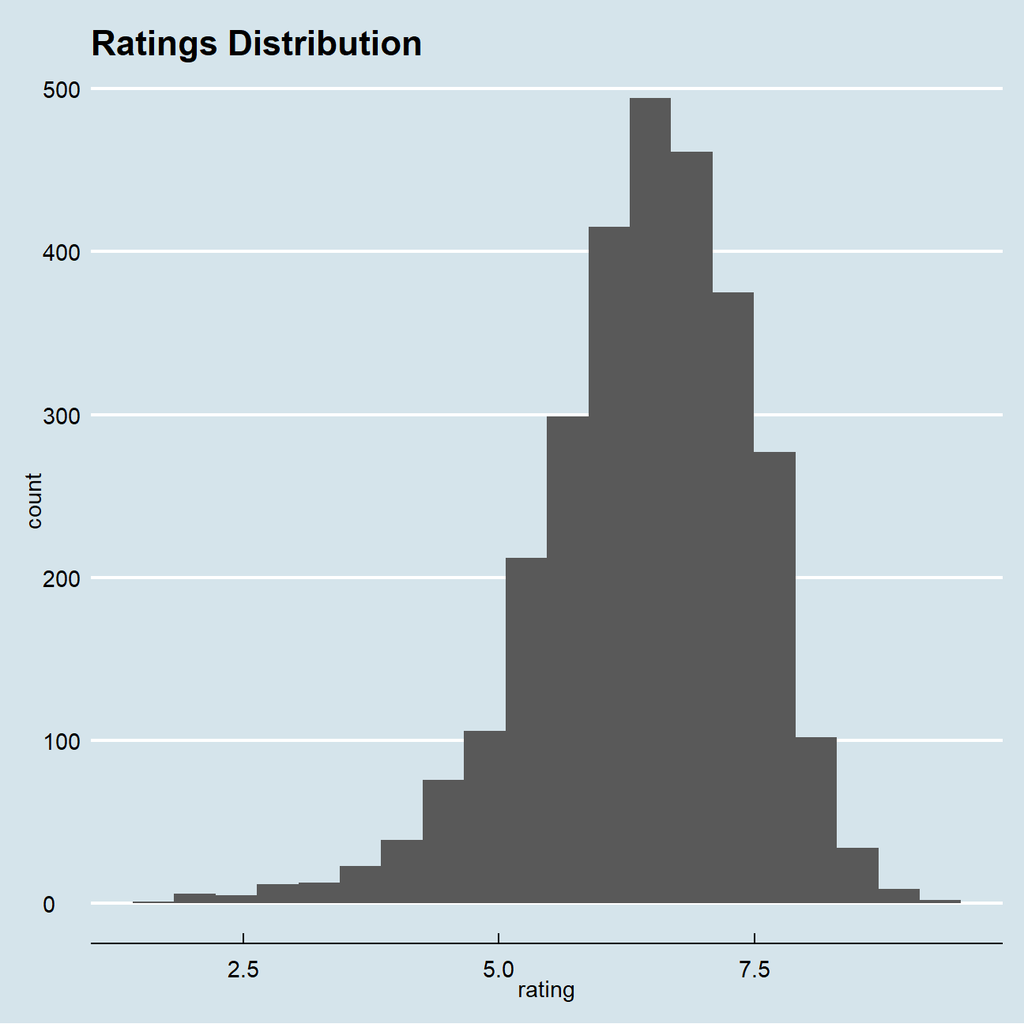

```r
# The below histogram indicates that on average a movie will likely have
# a rating of around 6 and that amazing and awful movies, getting extremely
# high or low ratings are rare.

  ggplot(data = movies, mapping = aes(x = rating)) +
  geom_histogram(bins = 20) +
  labs(title = "Ratings Distribution") +
  theme_economist()
```

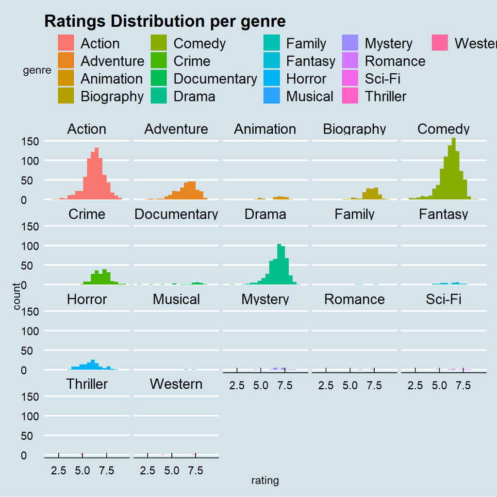

```r
  ggplot(data = movies, mapping = aes(x = rating, fill = genre)) +
  geom_histogram(bins = 20) +
  labs(title = "Ratings Distribution per genre") +
  theme_economist() +
  facet_wrap(~genre)
```

## 2.2 Use `ggplot` to answer the following

- Examine the relationship between `gross` and `cast_facebook_likes`. Produce a scatterplot and write one sentence discussing whether the number of facebook likes that the cast has received is likely to be a good predictor of how much money a movie will make at the box office. What variable are you going to map to the Y- and X- axes?

[figure not shown]

```r
ggplot(data=movies, mapping = aes(x = cast_facebook_likes, y = gross)) +
  geom_point(alpha = 0.2, position = "jitter") +
  labs(title = "Relationship between a movie's cast's FB likes and its gross earnings",
       y="Facebook likes",
       x="Gross Earnings ($)") +
  theme_economist() +
  scale_y_log10() +
  scale_x_log10()
```

As facebook likes is the independent variable, we mapped this on the x-axis, and gross, which is speculated to be dependent on FB likes, this was mapped on the y-axis. In light of the plot above however, we can conclude that the number of facebook likes that the cast has received are not a good predictor of how much money a movie will make at the box office.

- Examine the relationship between `gross` and `budget`. Produce a scatterplot and write one sentence discussing whether budget is likely to be a good predictor of how much money a movie will make at the box office.

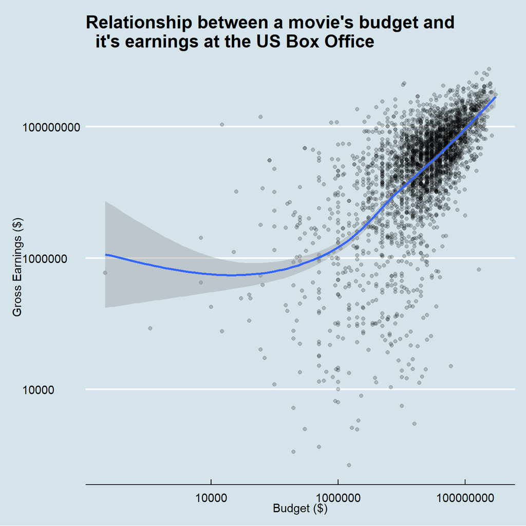

```r
ggplot(data=movies, mapping = aes(x = budget, y = gross)) +
  geom_point(alpha = 0.2) +
  labs(title = "Relationship between a movie's budget and
  it's earnings at the US Box Office", x = "Budget ($)", y = "Gross Earnings ($)") +
  theme_economist() +
  geom_smooth() +
  scale_y_log10() +
  scale_x_log10()
```

The scatter plot indicates a positive correlation between the budget for a movie and its gross earnings.

- Examine the relationship between `gross` and `rating`. Produce a scatterplot, faceted by `genre` and discuss whether IMDB ratings are likely to be a good predictor of how much money a movie will make at the box office. Is there anything strange in this dataset?

We see there is a positive correlation between rating and gross earnings across most of the genres, however strangely, this does not seem to be true for Sci-fi and Documentaries.

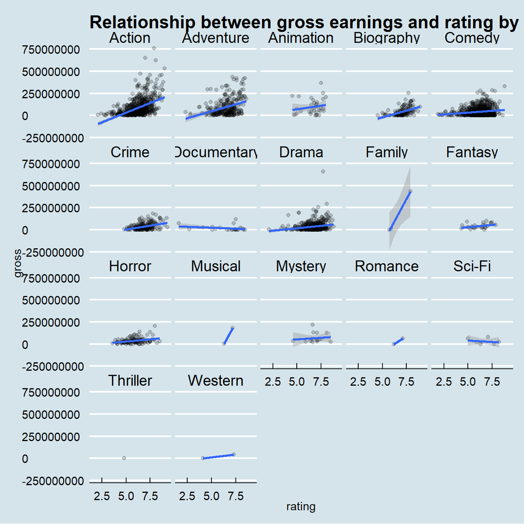

```r
ggplot(data = movies, mapping = aes(x = rating, y = gross)) +
  geom_point(alpha = 0.2) +
  labs(title = "Relationship between gross earnings and rating by genre") +
  facet_wrap(~ genre) +
  theme_economist() +
  geom_smooth(method = "lm")
```

# 3 Returns of financial stocks

> You may find useful the material on [finance data sources](https://mam2021.netlify.app/reference/finance_data/).

We will use the `tidyquant` package to download historical data of stock prices, calculate returns, and examine the distribution of returns.

We must first identify which stocks we want to download data for, and for this we must know their ticker symbol; Apple is known as AAPL, Microsoft as MSFT, McDonald’s as MCD, etc. The file `nyse.csv` contains 508 stocks listed on the NYSE, their ticker `symbol`, `name`, the IPO (Initial Public Offering) year, and the sector and industry the company is in.

```r
nyse <- read_csv(here::here("data","nyse.csv"))
```

Based on this dataset, create a table and a bar plot that shows the number of companies per sector, in descending order

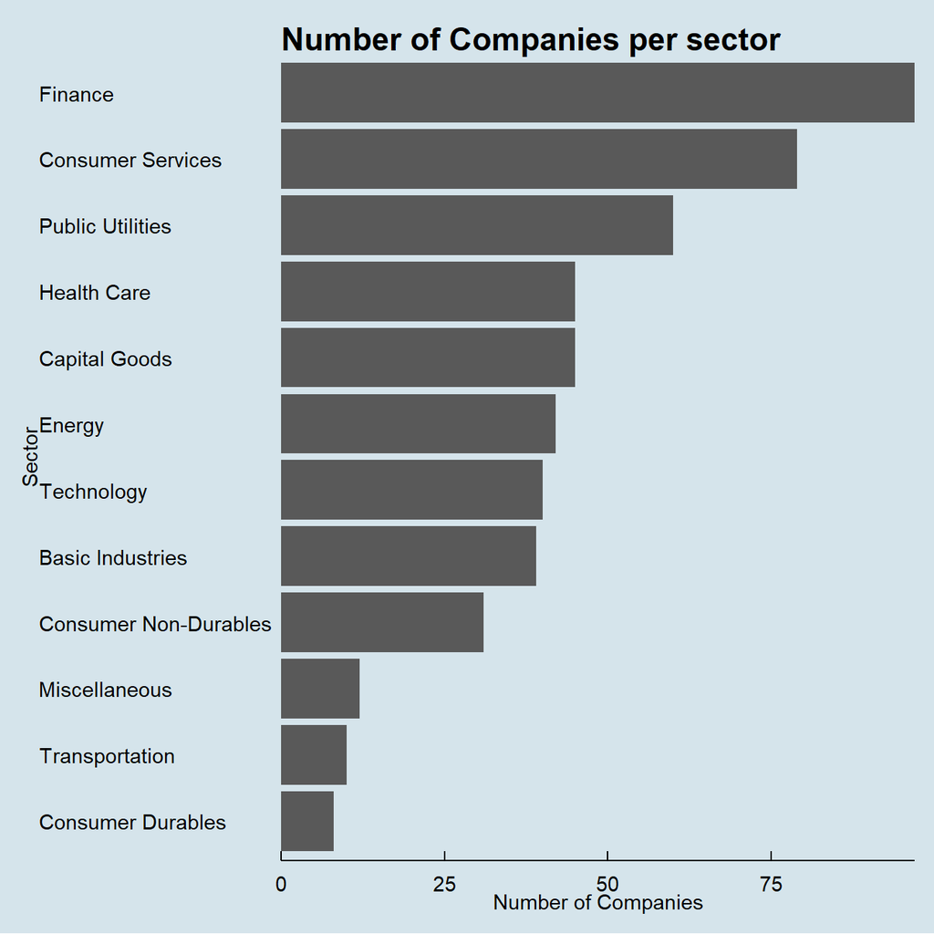

```r
# Creating df_comp that has companies per sector
df_comp <- nyse %>%
  #Grouping companies by sector and using tally to count number of companies in each sector
  group_by(sector) %>%
  tally()%>%
  #putting list in descending order
  arrange(n)
#creating a bar chart
ggplot(df_comp, aes(x= n , y = reorder(sector, n) )) +
    geom_col() +
  #Adjusting chart and axes titles
    ylab('Sector') +
    xlab('Number of Companies') +
    labs(title = 'Number of Companies per sector') +
  #Changing theme
    theme_economist() +
  #removing the gap between y axis and the start of bar graph
    scale_x_continuous(expand = c(0,0))+
  #removing panel background and border, gridlines,and axis lines and tick marks
    theme(panel.background =element_blank(), panel.border =  element_blank(),
           panel.grid.major  = element_blank() , panel.grid.minor = element_blank(), axis.ticks.y = element_blank() , axis.line.y = element_blank(),)
```

```r
comp_df <- df_comp %>%
  arrange(desc(n)) %>%
  rename('Sector' = 'sector' , 'Number of Companies' = 'n')


kbl(comp_df)%>%
  kable_styling()
```

| Sector | Number of Companies |
| --- | --- |
| Finance | 97 |
| Consumer Services | 79 |
| Public Utilities | 60 |
| Capital Goods | 45 |
| Health Care | 45 |
| Energy | 42 |
| Technology | 40 |
| Basic Industries | 39 |
| Consumer Non-Durables | 31 |
| Miscellaneous | 12 |
| Transportation | 10 |
| Consumer Durables | 8 |

Next, let’s choose some stocks and their ticker symbols and download some data. You **MUST** choose 6 different stocks from the ones listed below; You should, however, add `SPY` which is the SP500 ETF (Exchange Traded Fund).

```r
# Notice the cache=TRUE argument inthe chunk options. Because getting data is time consuming,
# cache=TRUE means that once it downloads data, the chunk will not run again next time you knit your Rmd

myStocks <- c("ANET","DELL","HPE","INFY","PINS","SNAP","SPY" ) %>%
  tq_get(get  = "stock.prices",
         from = "2011-01-01",
         to   = "2020-08-31") %>%
  group_by(symbol)

glimpse(myStocks) # examine the structure of the resulting data frame
```

```
## Rows: 9,899
## Columns: 8
## Groups: symbol [7]
## $ symbol   <chr> "ANET", "ANET", "ANET", "ANET", "ANET", "ANET", "ANET", "A...
## $ date     <date> 2014-06-06, 2014-06-09, 2014-06-10, 2014-06-11, 2014-06-1...
## $ open     <dbl> 55.2, 56.2, 55.2, 60.0, 63.7, 68.5, 71.2, 71.9, 70.1, 68.0...
## $ high     <dbl> 60.0, 57.0, 60.0, 63.5, 67.8, 72.0, 71.5, 72.6, 71.0, 68.8...
## $ low      <dbl> 55.0, 55.0, 55.2, 58.7, 63.1, 67.0, 67.6, 69.0, 67.9, 64.5...
## $ close    <dbl> 55.0, 55.2, 60.0, 63.5, 66.0, 69.6, 71.5, 69.7, 69.0, 65.7...
## $ volume   <dbl> 7255100, 716900, 986800, 660500, 729300, 1065700, 417000, ...
## $ adjusted <dbl> 55.0, 55.2, 60.0, 63.5, 66.0, 69.6, 71.5, 69.7, 69.0, 65.7...
```

Financial performance analysis depend on returns; If I buy a stock today for 100 and I sell it tomorrow for 101.75, my one-day return, assuming no transaction costs, is 1.75%. So given the adjusted closing prices, our first step is to calculate daily and monthly returns.

```r
#calculate daily returns
myStocks_returns_daily <- myStocks %>%
  tq_transmute(select     = adjusted,
               mutate_fun = periodReturn,
               period     = "daily",
               type       = "log",
               col_rename = "daily_returns",
               cols = c(nested.col))

#calculate monthly  returns
myStocks_returns_monthly <- myStocks %>%
  tq_transmute(select     = adjusted,
               mutate_fun = periodReturn,
               period     = "monthly",
               type       = "arithmetic",
               col_rename = "monthly_returns",
               cols = c(nested.col))

#calculate yearly returns
myStocks_returns_annual <- myStocks %>%
  group_by(symbol) %>%
  tq_transmute(select     = adjusted,
               mutate_fun = periodReturn,
               period     = "yearly",
               type       = "arithmetic",
               col_rename = "yearly_returns",
               cols = c(nested.col))
```

Create a table where you summarise monthly returns for each of the stocks and `SPY`; min, max, median, mean, SD.

```r
#creating sum_month for summary statistics for each stock
sum_month <- myStocks_returns_monthly %>%
  group_by(symbol)%>%
  summarize(
            min = round(min(monthly_returns),2),
            max = round(max(monthly_returns),2),
            median = round(median(monthly_returns),2),
            mean = round(mean(monthly_returns),2) ,
            SD = round(sd(monthly_returns),2)) %>%
  rename(., c("Symbol" = "symbol" , 'Min' = 'min' , 'Max' = 'max' , 'Median' = 'median' , 'Mean' = 'mean'))

#using kabble to display sum_month
sum_month %>%
  kbl() %>%
  kable_styling()
```

[output not shown]

Plot a density plot, using `geom_density()`, for each of the stocks

[figure not shown]

```r
#Desinty Plot for monthly returns
  ggplot(myStocks_returns_monthly, aes(monthly_returns,fill = symbol,)) +
  #changing transperancy of chart
    geom_density(alpha = 0.2) +
    theme_solarized()+
  #adding titles
    ylab('Density') +
    xlab('Monthly Returns') +
    labs(title = 'Distribution of Monthly Returns for each stock',
           fill = 'Stock Symbol'
           ) +
  #adding themes
    theme_economist() +
  #removing gaps betweens chart panel and the axis
    scale_x_continuous(expand = c(0,0))+
    scale_y_continuous(expand = c(0,0))+
  #removing panel background and border, gridlines,and axis lines and tick marks
      theme(panel.background =element_blank(), panel.border =  element_blank(),
             panel.grid.major  = element_blank() , panel.grid.minor = element_blank(), axis.ticks.y = element_blank() , axis.line.y = element_line(), legend.position = "none")+
  #creating a faceted graph
     facet_grid(symbol ~ .,)
```

What can you infer from this plot? Which stock is the riskiest? The least risky?

> TYPE YOUR ANSWER AFTER (AND OUTSIDE!) THIS BLOCKQUOTE.

We understand that risk is a function of implied volatility and price-deviation from expected returns. Our analysis on the data above suggests that stocks with fatter tails represent higher volatility, and hence have a higher risk profile.

Finally, make a plot that shows the expected monthly return (mean) of a stock on the Y axis and the risk (standard deviation) in the X-axis. Please use `ggrepel::geom_text_repel()` to label each stock

[figure not shown]

```r
# creating df for mean and sd

meanSD_df <- myStocks_returns_monthly %>%
  group_by(symbol)%>%
  summarize(
            mean = round(mean(monthly_returns),4) ,
            SD = round(sd(monthly_returns),4)) %>%
  rename('Mean' = 'mean')



# plotting the graph
ggplot(meanSD_df , aes(x = SD , y = Mean , label = symbol ,)) +
  geom_point(shape = 21 , aes(fill = symbol) , size = 4) +
  geom_text_repel(nudge_x = 0.01)+
  theme_economist()+
  scale_fill_solarized()+
  labs(title= 'Scatter plot of Mean vs SD', x = 'Standard Deviation' , y = 'Mean' , fill = 'Symbol') +

  # removing panel background and border, gridlines,and axis lines and tick marks
  theme(panel.background =element_blank(),
      panel.border =  element_blank(),
      panel.grid.major  = element_blank() ,
      panel.grid.minor = element_blank(),
      axis.ticks.y = element_blank() ,
      axis.line.y = element_line(),
      legend.position = "right" ,
      legend.background = element_blank(),
      legend.key = element_blank(),
      axis.title = element_text(face = 'bold'),
      plot.title = element_text(face = 'bold')) +

  # adding linear regression
  geom_smooth(method = "lm", se = FALSE , colour = 'black' , size = .1 ,linetype  = 'dotted')
```

What can you infer from this plot? Are there any stocks which, while being riskier, do not have a higher expected return?

> TYPE YOUR ANSWER AFTER (AND OUTSIDE!) THIS BLOCKQUOTE.

The above graph represents the mean vs the standard deviation for the various stocks. In addition to the above, a regression has been performed to ascertain the risk-return profile of the selected stocks. The regression represents the linear relationship between the expected return and the standard deviation, for illustrative purposes.

# 4 On your own: IBM HR Analytics

For this task, you will analyse a data set on Human Resoruce Analytics. The [IBM HR Analytics Employee Attrition & Performance data set](https://www.kaggle.com/pavansubhasht/ibm-hr-analytics-attrition-dataset) is a fictional data set created by IBM data scientists. Among other things, the data set includes employees’ income, their distance from work, their position in the company, their level of education, etc. A full description can be found on the website.

First let us load the data.

```r
hr_dataset <- read_csv(here::here("data", "datasets_1067_1925_WA_Fn-UseC_-HR-Employee-Attrition.csv"))
glimpse(hr_dataset)
```

```
## Rows: 1,470
## Columns: 35
## $ Age                      <dbl> 41, 49, 37, 33, 27, 32, 59, 30, 38, 36, 35...
## $ Attrition                <chr> "Yes", "No", "Yes", "No", "No", "No", "No"...
## $ BusinessTravel           <chr> "Travel_Rarely", "Travel_Frequently", "Tra...
## $ DailyRate                <dbl> 1102, 279, 1373, 1392, 591, 1005, 1324, 13...
## $ Department               <chr> "Sales", "Research & Development", "Resear...
## $ DistanceFromHome         <dbl> 1, 8, 2, 3, 2, 2, 3, 24, 23, 27, 16, 15, 2...
## $ Education                <dbl> 2, 1, 2, 4, 1, 2, 3, 1, 3, 3, 3, 2, 1, 2, ...
## $ EducationField           <chr> "Life Sciences", "Life Sciences", "Other",...
## $ EmployeeCount            <dbl> 1, 1, 1, 1, 1, 1, 1, 1, 1, 1, 1, 1, 1, 1, ...
## $ EmployeeNumber           <dbl> 1, 2, 4, 5, 7, 8, 10, 11, 12, 13, 14, 15, ...
## $ EnvironmentSatisfaction  <dbl> 2, 3, 4, 4, 1, 4, 3, 4, 4, 3, 1, 4, 1, 2, ...
## $ Gender                   <chr> "Female", "Male", "Male", "Female", "Male"...
## $ HourlyRate               <dbl> 94, 61, 92, 56, 40, 79, 81, 67, 44, 94, 84...
```

[output cut: 22 more lines]

I am going to clean the data set, as variable names are in capital letters, some variables are not really necessary, and some variables, e.g., `education` are given as a number rather than a more useful description

```r
hr_cleaned <- hr_dataset %>%
  clean_names() %>%
  mutate(
    education = case_when(
      education == 1 ~ "Below College",
      education == 2 ~ "College",
      education == 3 ~ "Bachelor",
      education == 4 ~ "Master",
      education == 5 ~ "Doctor"
    ),
    environment_satisfaction = case_when(
      environment_satisfaction == 1 ~ "Low",
      environment_satisfaction == 2 ~ "Medium",
      environment_satisfaction == 3 ~ "High",
      environment_satisfaction == 4 ~ "Very High"
    ),
    job_satisfaction = case_when(
      job_satisfaction == 1 ~ "Low",
      job_satisfaction == 2 ~ "Medium",
      job_satisfaction == 3 ~ "High",
      job_satisfaction == 4 ~ "Very High"
    ),
    performance_rating = case_when(
      performance_rating == 1 ~ "Low",
      performance_rating == 2 ~ "Good",
      performance_rating == 3 ~ "Excellent",
      performance_rating == 4 ~ "Outstanding"
    ),
    work_life_balance = case_when(
      work_life_balance == 1 ~ "Bad",
      work_life_balance == 2 ~ "Good",
      work_life_balance == 3 ~ "Better",
      work_life_balance == 4 ~ "Best"
    )
  ) %>%
  select(age, attrition, daily_rate, department,
         distance_from_home, education,
         gender, job_role,environment_satisfaction,
         job_satisfaction, marital_status,
         monthly_income, num_companies_worked, percent_salary_hike,
         performance_rating, total_working_years,
         work_life_balance, years_at_company,
         years_since_last_promotion)
```

## 4.1 Attrition Behaviour

The attrition rate of the copmany is given by the number of employees who have left (Attrition == “Yes”) divided by the total number of employees. As shown below, the attrition rate calculated from this dataset is 16.1%.

```r
attrition_emp <- hr_cleaned %>% filter(attrition=="Yes") %>% count()
total_emp <- hr_cleaned %>% count()
(attrition_emp/total_emp) %>%
  rename(.,c("Attrition Rate"= "n"))
```

```
##   Attrition Rate
## 1          0.161
```

Filtering the dataset by the employees who have left the company, we see that the average number of years they spent at IBM before quitting is 5.13 years.

```r
# Calculate average working years of people whose attrition is "yes".
quit<- hr_cleaned %>% filter(attrition=='Yes') %>%
  summarize(mean(years_at_company)) %>%
  rename(.,c("Average years at IBM"= "mean(years_at_company)"))
quit
```

```
## # A tibble: 1 x 1
##   `Average years at IBM`
##                    <dbl>
## 1                   5.13
```

We further investigate the average number of years an employee stays at any company, which is calculated by the sum of total working years of all employees divided by the total number of companies worked for of all employees.

```r
# Calculate total working year for all stuff
sum_work_year <- hr_cleaned %>%
  summarise(sum(total_working_years))

# Calculate total number of companies for all stuff
sum_num_company <- hr_cleaned %>%
  summarise(sum(num_companies_worked))

# Calculate frequency of people leaving the company
leave_fre <- sum_work_year/sum_num_company
leave_fre %>%
  rename(.,c("Average years at 1 company"= "sum(total_working_years)"))
```

```
##   Average years at 1 company
## 1                       4.19
```

As seen above, the average number of years at any 1 company is 4.19 years, which is lower than the average years at IBM. We can therefore argue that IBM appears to be a more desirable workplace than the average company which the employees have worked in.

## 4.2 Distribution of various variables

```r
summary(hr_cleaned[,c("age","years_at_company","monthly_income","years_since_last_promotion")])
```

```
##       age       years_at_company monthly_income  years_since_last_promotion
##  Min.   :18.0   Min.   : 0       Min.   : 1009   Min.   : 0.00
##  1st Qu.:30.0   1st Qu.: 3       1st Qu.: 2911   1st Qu.: 0.00
##  Median :36.0   Median : 5       Median : 4919   Median : 1.00
##  Mean   :36.9   Mean   : 7       Mean   : 6503   Mean   : 2.19
##  3rd Qu.:43.0   3rd Qu.: 9       3rd Qu.: 8379   3rd Qu.: 3.00
##  Max.   :60.0   Max.   :40       Max.   :19999   Max.   :15.00
```

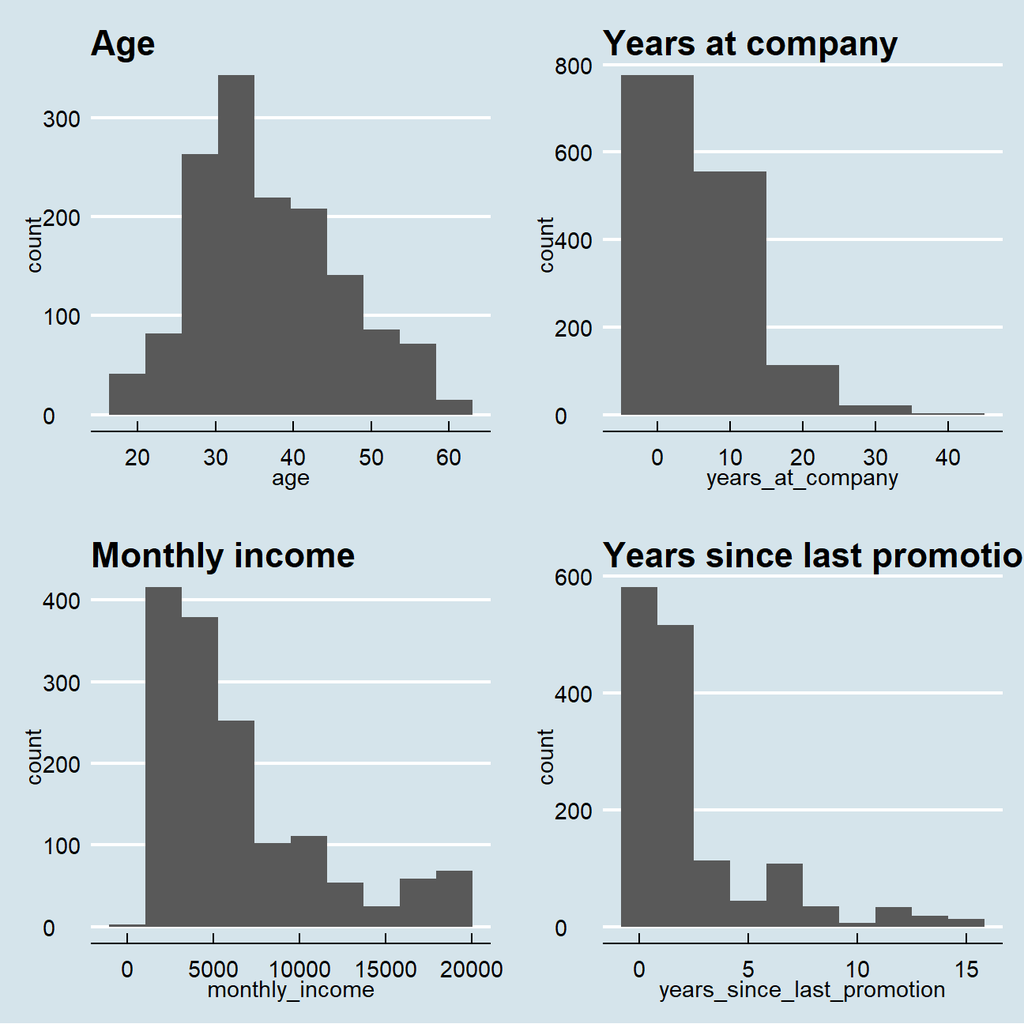

```r
# Histogram of age
age_plot <- ggplot(hr_cleaned, aes(x = age )) +
  geom_histogram(bins=10)+
  labs(title = "Age")+
  theme_economist()

# Histogram of years_at_company
years_plot <- ggplot(hr_cleaned, aes(x = years_at_company )) +
  geom_histogram(bins=5)+
  labs(title = "Years at company")+
  theme_economist()

# Histogram of monthly_income
monthly_plot <- ggplot(hr_cleaned, aes(x = monthly_income )) +
  geom_histogram(bins=10)+
  labs(title = "Monthly income")+
  theme_economist()

# Histogram of years_since_last_promotion
promotion_plot <- ggplot(hr_cleaned, aes(x = years_since_last_promotion )) +
  geom_histogram(bins=10)+
  labs(title = "Years since last promotion")+
  theme_economist()



grid.arrange(age_plot,years_plot, monthly_plot, promotion_plot,ncol=2)
```

According to the histograms in question 2, we can see “age” is distributed closer to Normal Distribution. This indicates that the age of IBM employees is normally distributed. The distributions of “years_at_company”, “monthly_income” and “years_since_last_promotion” skew to the right. The distributions tell us most employees stay in company less than 20 years, their salaries are concentrated in areas less than 1,0000 dollars per month and most of the employees get promotion every one to five years.

From the summary statistics, we can also guess that age is closest to normal from the difference between the quantiles.

## 4.3 Work Satisfaction

As it is easier to construct a histogram with the numerical rating categories, we decided to use original dataset because its much easier to make the histogram of work-life balance and job satisfaction.

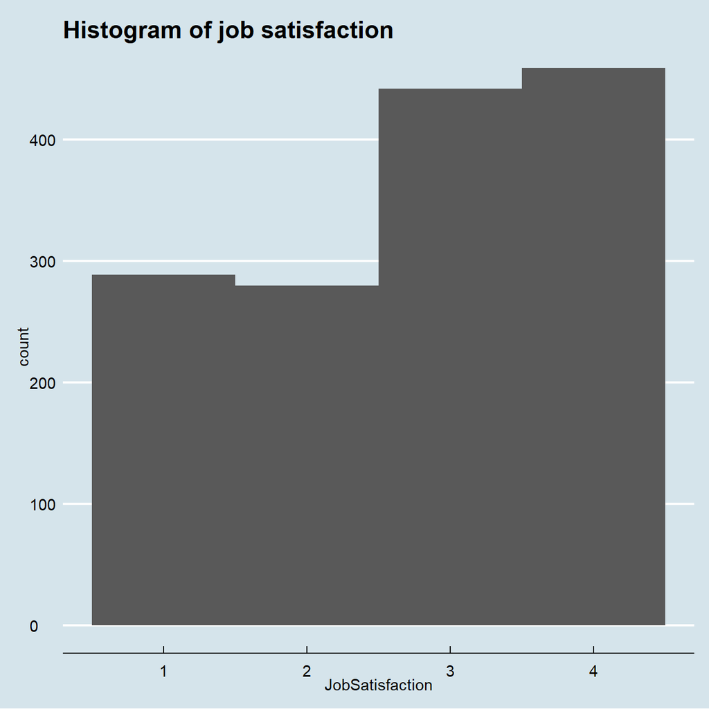

```r
# Histogram of job_satisfaction
ggplot(hr_dataset, aes(x = JobSatisfaction )) +
  geom_histogram(bins=4)+
  labs(title = "Histogram of job satisfaction")+
  theme_economist()
```

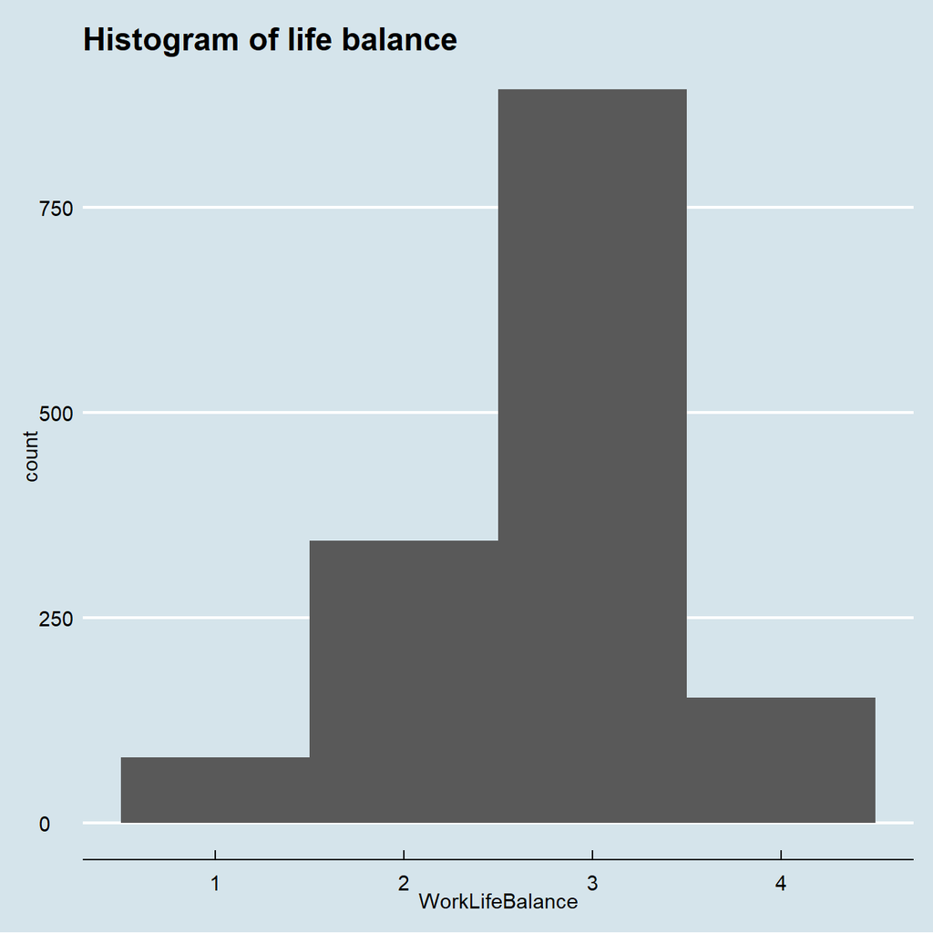

```r
# Histogram of work_life_balance
ggplot(hr_dataset, aes(x = WorkLifeBalance )) +
  geom_histogram(bins=4)+
  labs(title = "Histogram of life balance")+
  theme_economist()
```

```r
# Count job satisfaction
count_job_satisfaction <- hr_cleaned %>% count(job_satisfaction)

# Percentage of job satisfaction
percent_job_satisfaction <- count_job_satisfaction[,2]/sum(count_job_satisfaction[,2])
count_job_satisfaction %>%
  rename(.,c("Count"= "n","Job Satisfaction"="job_satisfaction")) %>%
  cbind(percent_job_satisfaction) %>%
  rename(.,c("Percentage"= "n"))
```

```
##   Job Satisfaction Count Percentage
## 1             High   442      0.301
## 2              Low   289      0.197
## 3           Medium   280      0.190
## 4        Very High   459      0.312
```

```r
# Count work life balance
count_work_life_balance <- hr_cleaned %>% count(work_life_balance)
# percentage of work life balance
percent_work_life_balance <- count_work_life_balance[,2]/sum(count_work_life_balance[,2])

count_work_life_balance %>%
  rename(.,c("Count"= "n","Work-Life Balance"="work_life_balance")) %>%
  cbind(percent_work_life_balance) %>%
  rename(.,c("Percentage"= "n"))
```

```
##   Work-Life Balance Count Percentage
## 1               Bad    80     0.0544
## 2              Best   153     0.1041
## 3            Better   893     0.6075
## 4              Good   344     0.2340
```

We can see “job_satisfaction” slightly skew to the left, which means majority of people are satisfied while there are still many people who are not satisfied with their current job. Employees’ work-life balance are closer to normal distribution. From the percentage chart, we know most people (61%) give “Better” in the survey.

## 4.4 Analysis of Monthly income

### 4.4.1 Education Level

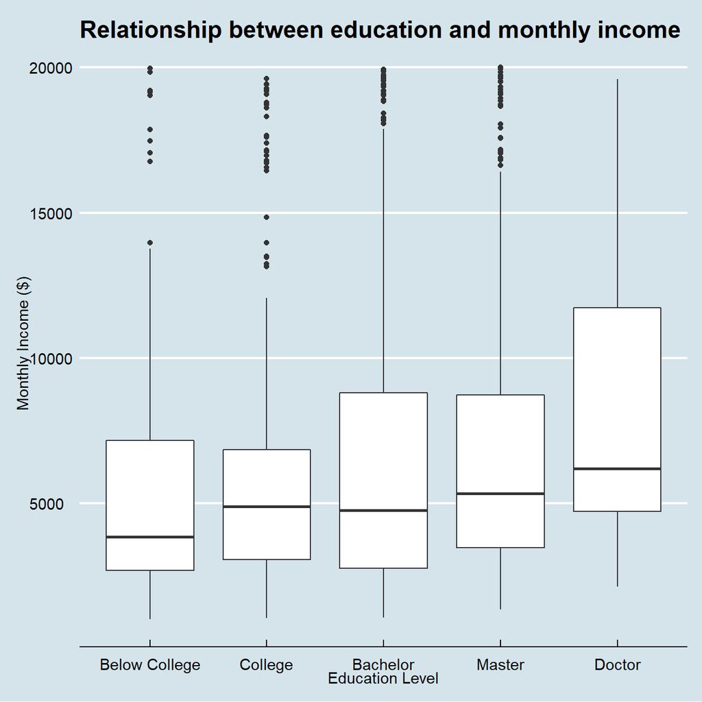

```r
# boxplot to see the relationship between eductaion and monthly income
ggplot(hr_cleaned, aes(x = reorder(education,monthly_income), y=monthly_income,levels=)) +
  geom_boxplot() +
  labs(
    title = "Relationship between education and monthly income",
    x="Education Level",
    y="Monthly Income ($)"
       )+
  theme_economist()
```

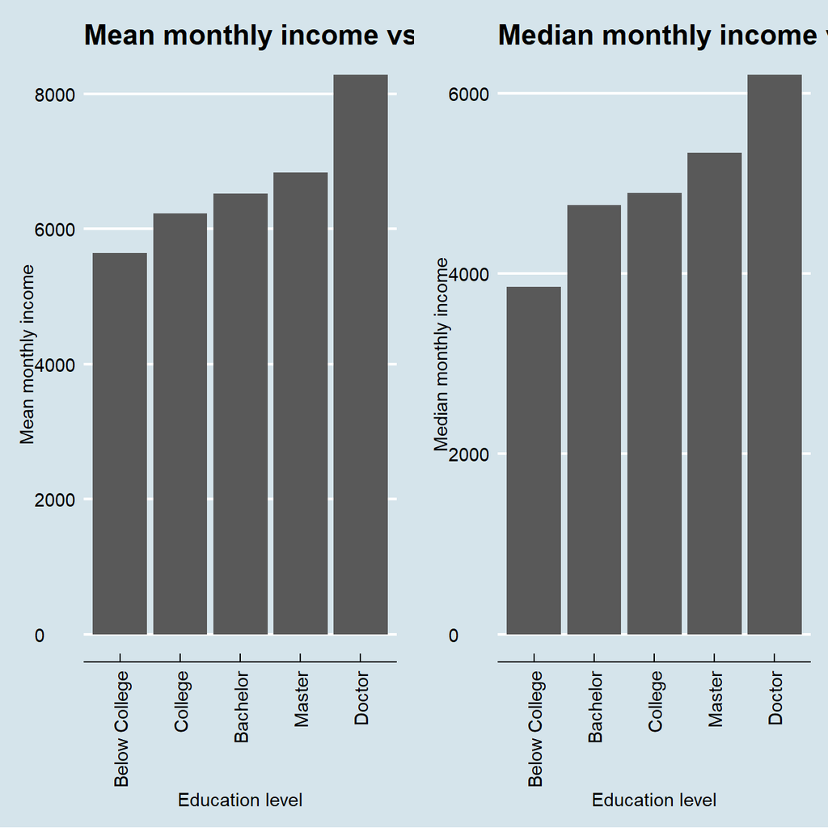

```r
mean_education_level <- hr_cleaned %>%
  group_by(education)%>%
  summarise(mean_income = mean(monthly_income))

mean_plot <- ggplot(mean_education_level,aes(x=reorder(education,mean_income), y= mean_income))+
  geom_col()+
  labs(title = "Mean monthly income vs Education", x="Education level", y= "Mean monthly income") +
  theme_economist() +
  theme(axis.text.x = element_text(angle=90,vjust=0.5,hjust=1))

med_education_level <- hr_cleaned %>%
  group_by(education)%>%
  summarise(med_income = median(monthly_income))

med_plot <- ggplot(med_education_level,aes(x=reorder(education,med_income), y= med_income))+
  geom_col()+
  labs(title = "Median monthly income vs Education", x="Education level", y= "Median monthly income") +
  theme_economist() +
  theme(axis.text.x = element_text(angle=90,vjust=0.5,hjust=1))

grid.arrange(mean_plot,med_plot,ncol=2)
```

### 4.4.2 Gender

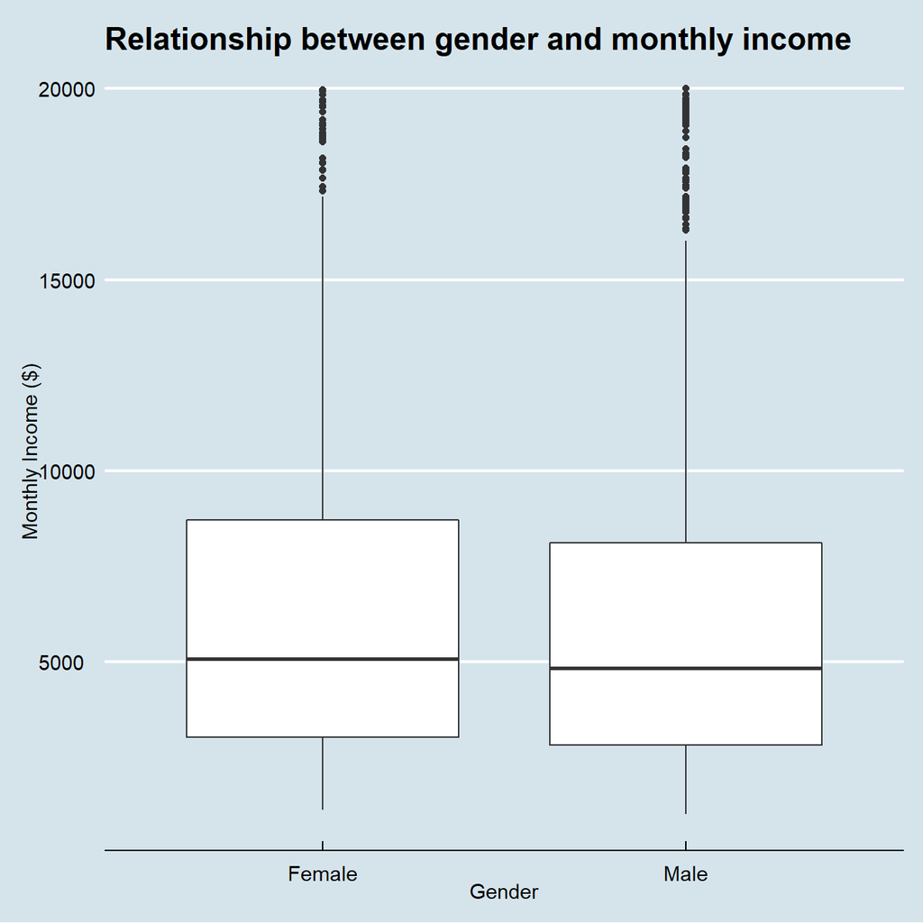

```r
# boxplot to see the relationship between gender and monthly income
ggplot(hr_cleaned, aes(x = gender, y=monthly_income)) +
  geom_boxplot() +
  labs(title = "Relationship between gender and monthly income",
    x="Gender",
    y="Monthly Income ($)"
    )+
  theme_economist()
```

From the box plot graph comparing the monthly income between the males and females, the monthly income of females seem to be slightly higher than that of males,which is a surprising result since IBM is a male-dominated tech company. However, the difference is not very significant.

### 4.4.3 Job Role

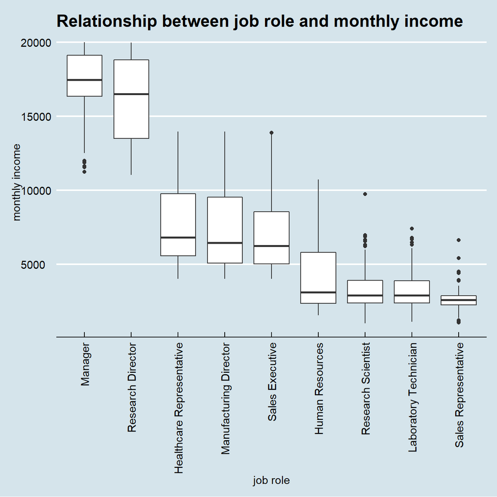

```r
# boxplot to see the relationship job role and monthly income
ggplot(hr_cleaned, aes(x = reorder(job_role,-monthly_income), y=monthly_income)) +
  geom_boxplot() +
  labs(title = "Relationship between job role and monthly income", x="job role", y= "monthly income") +
  theme_economist() +
  theme(axis.text.x = element_text(angle=90,vjust=0.5,hjust=1))
```

From the plot, managers and research directors have highest income. Sales representative, laboratory technician and research scientist have lowest income.

## 4.5 Distribution of Income over different factors

### 4.5.1 Education Level

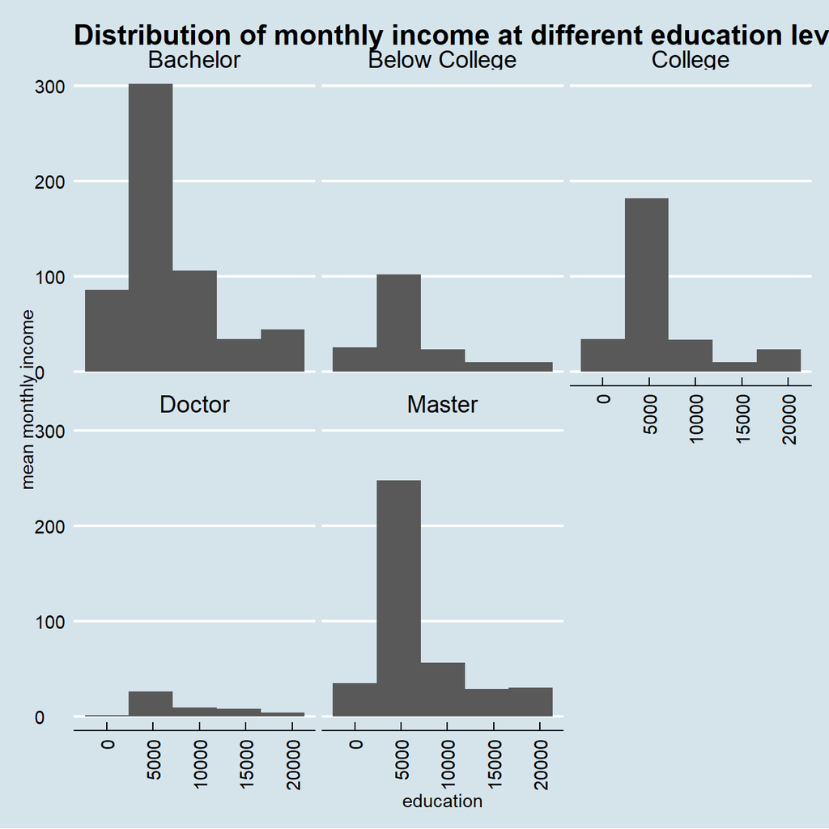

```r
ggplot(hr_cleaned,aes(x= monthly_income))+
  geom_histogram(bins=5)+
  facet_wrap(~education)+
  labs(title = "Distribution of monthly income at different education levels",
       x="education",
       y= "mean monthly income") +
  theme_economist() +
  theme(axis.text.x = element_text(angle=90,vjust=0.5,hjust=1))
```

### 4.5.2 Job Role

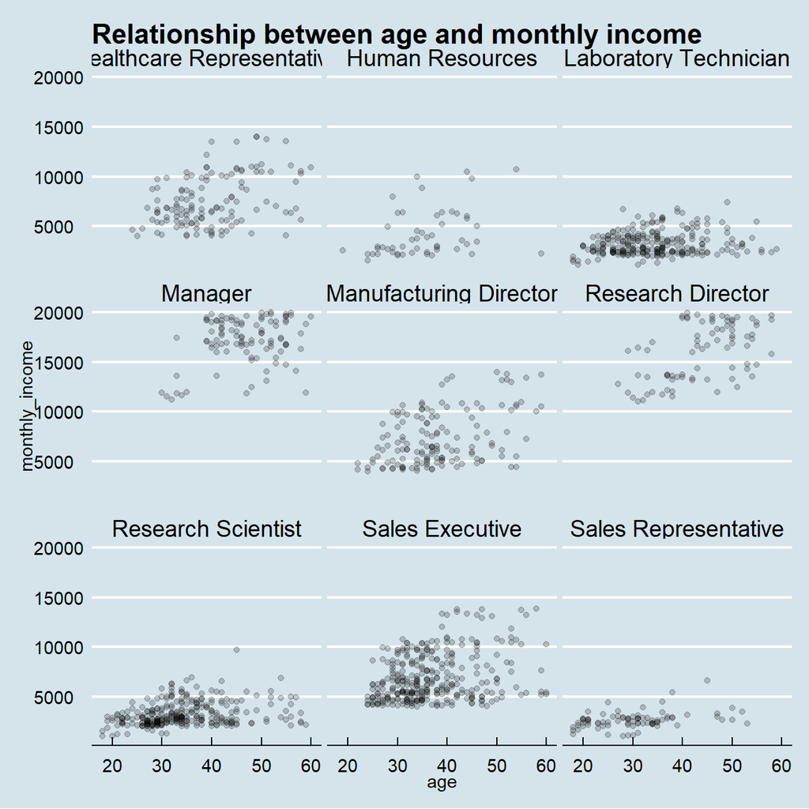

```r
ggplot(hr_cleaned,aes(x=age, y=monthly_income))+
  geom_point(alpha=0.2)+
  facet_wrap(~job_role)+
  labs(title = "Relationship between age and monthly income")+
  theme_economist()
```

We were wondering if people get higher income if they are older. The scatter plot tells us this is not true. The salary depends on the job position instead of your age. Managers and research directors always have higher income no matter what age they are.

## 4.6 Further exploration and other statistics.

Our group is interested in the relationship between employees’ marital status and other variables. From the histogram of “Relationship between marriage and work life balance”, we have seen marital status will not affect employee’s work life balance since the histograms have similar distribution.

Further, we want to compare women and men’s monthly income in terms of their marital status. We hypothesized that there would be a big difference since women always “have more responsibility” to take care of their families. However, histograms show similar distribution for women and men, with men having a greater number of high level incomes.

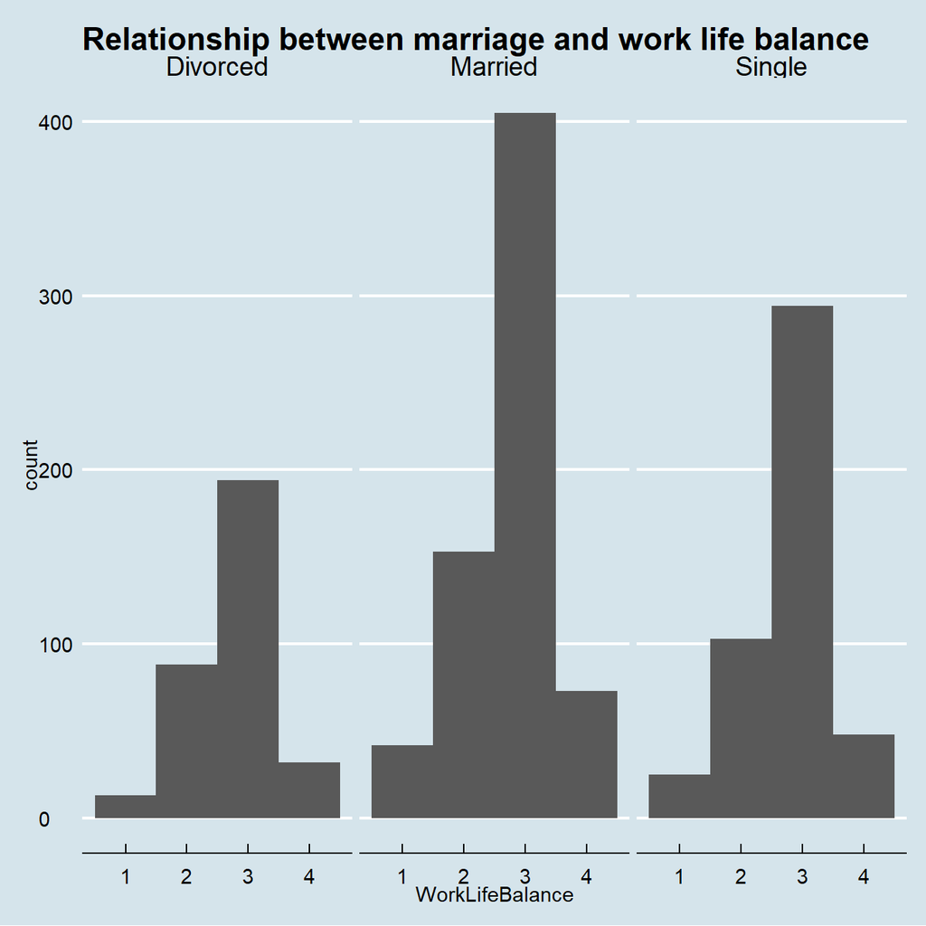

```r
ggplot(hr_dataset,aes(x= WorkLifeBalance))+
  geom_histogram(bins=4)+
  facet_wrap(~MaritalStatus)+
  labs(title = "Relationship between marriage and work life balance")+
  theme_economist()
```

```r
hr_female <- hr_dataset %>% filter (Gender=="Female")
hr_female
```

```
## # A tibble: 588 x 35
##      Age Attrition BusinessTravel DailyRate Department DistanceFromHome
##    <dbl> <chr>     <chr>              <dbl> <chr>                 <dbl>
##  1    41 Yes       Travel_Rarely       1102 Sales                     1
##  2    33 No        Travel_Freque~      1392 Research ~                3
##  3    59 No        Travel_Rarely       1324 Research ~                3
##  4    29 No        Travel_Rarely        153 Research ~               15
##  5    29 No        Travel_Rarely       1389 Research ~               21
##  6    53 No        Travel_Rarely       1219 Sales                     2
##  7    24 No        Non-Travel           673 Research ~               11
##  8    34 No        Travel_Rarely        419 Research ~                7
##  9    53 No        Travel_Rarely       1282 Research ~                5
## 10    32 Yes       Travel_Freque~      1125 Research ~               16
## # ... with 578 more rows, and 29 more variables: Education <dbl>,
## #   EducationField <chr>, EmployeeCount <dbl>, EmployeeNumber <dbl>,
## #   EnvironmentSatisfaction <dbl>, Gender <chr>, HourlyRate <dbl>,
## #   JobInvolvement <dbl>, JobLevel <dbl>, JobRole <chr>, JobSatisfaction <dbl>,
## #   MaritalStatus <chr>, MonthlyIncome <dbl>, MonthlyRate <dbl>,
## #   NumCompaniesWorked <dbl>, Over18 <chr>, OverTime <chr>,
## #   PercentSalaryHike <dbl>, PerformanceRating <dbl>,
## #   RelationshipSatisfaction <dbl>, StandardHours <dbl>,
## #   StockOptionLevel <dbl>, TotalWorkingYears <dbl>,
## #   TrainingTimesLastYear <dbl>, WorkLifeBalance <dbl>, YearsAtCompany <dbl>,
## #   YearsInCurrentRole <dbl>, YearsSinceLastPromotion <dbl>,
## #   YearsWithCurrManager <dbl>
```

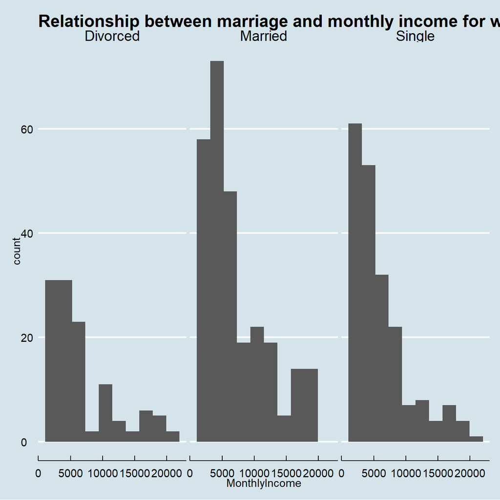

```r
ggplot(hr_female,aes(x= MonthlyIncome))+
  geom_histogram(bins=10)+
  facet_wrap(~MaritalStatus)+
  labs(title = "Relationship between marriage and monthly income for women")+
  theme_economist()
```

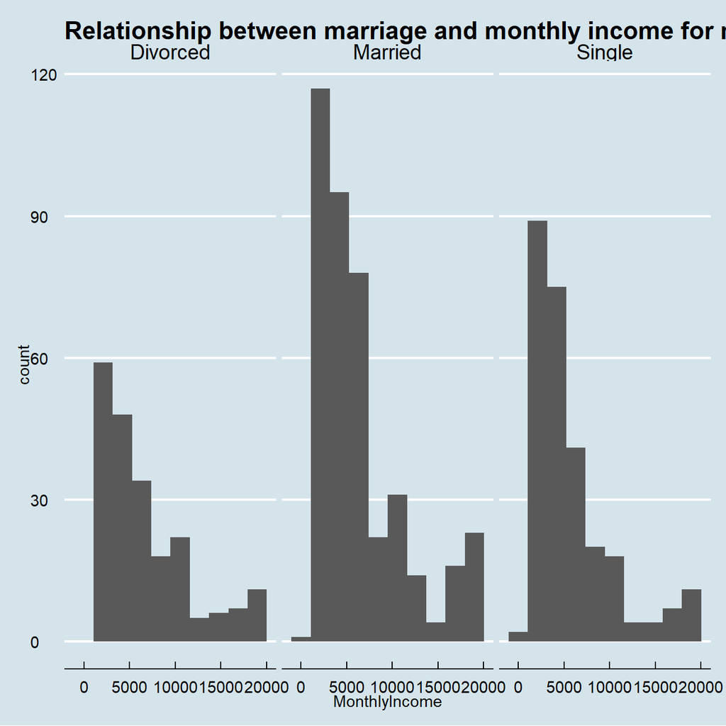

```r
hr_male <- hr_dataset %>% filter (Gender=="Male")
ggplot(hr_male,aes(x= MonthlyIncome))+
  geom_histogram(bins=10)+
  facet_wrap(~MaritalStatus)+
  labs(title = "Relationship between marriage and monthly income for men")+
  theme_economist()
```

# 5 Challenge 1: Replicating a chart

The purpose of this exercise is to make a publication-ready plot using your `dplyr` and `ggplot2` skills. Open the journal article “Riddell_Annals_Hom-Sui-Disparities.pdf”. Read the abstract and have a look at Figure 3. The data you need is “CDC_Males.csv”.

Don’t worry about replicating it exactly, try and see how far you can get. You’re encouraged to work together if you want to and exchange tips/tricks you figured out.

You may find these helpful:

- https://cran.r-project.org/web/packages/ggrepel/vignettes/ggrepel.html
- http://colorbrewer2.org

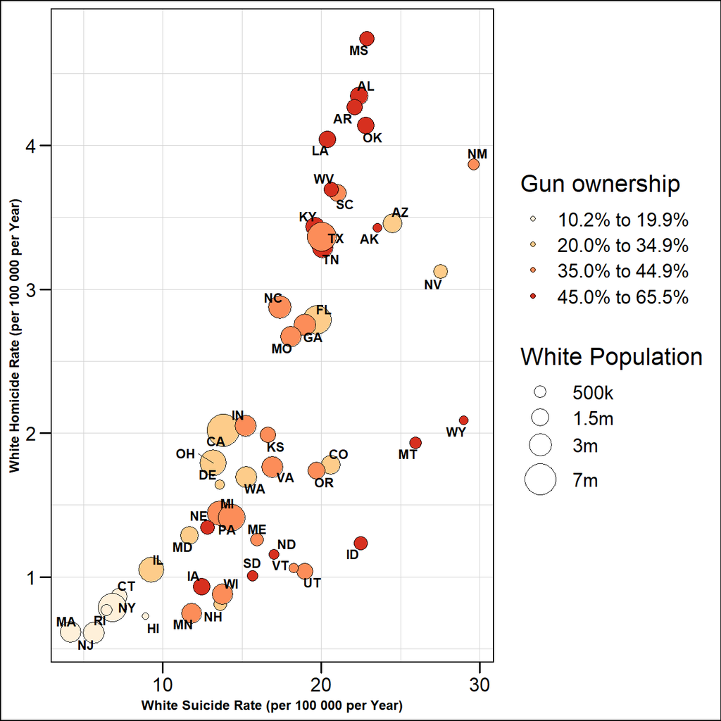

# 6 Challenge 2: 2016 California Contributors plots

As discussed in class, I would like you to reproduce the plot that shows the top ten cities in highest amounts raised in political contributions in California during the 2016 US Presidential election.

To get this plot, you must join two dataframes; the one you have with all contributions, and data that can translate zipcodes to cities. You can find a file with all US zipcodes, e.g., here http://www.uszipcodelist.com/download.html.

The easiest way would be to create two plots and then place one next to each other. For this, you will need the `patchwork` package. https://cran.r-project.org/web/packages/patchwork/index.html

While this is ok, what if one asked you to create the same plot for the top 10 candidates and not just the top two? The most challenging part is how to reorder within categories, and for this you will find Julia Silge’s post on [REORDERING AND FACETTING FOR GGPLOT2](https://juliasilge.com/blog/reorder-within/) useful.

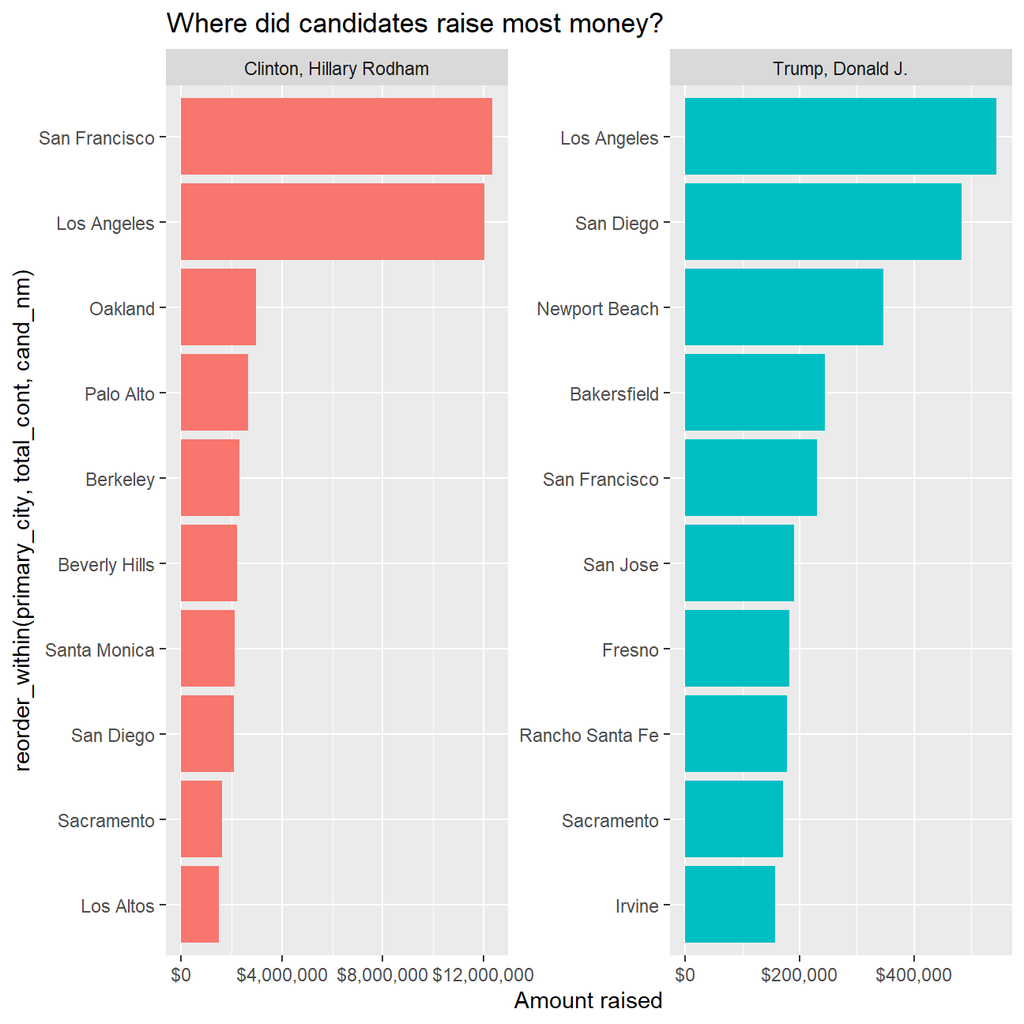

```r
# Make sure you use vroom() as it is significantly faster than read.csv()
library(patchwork)
library(tidytext)

# reading data for Trump and Hillary
CA_contributors_2016 <- vroom::vroom(here::here("data","CA_contributors_2016.csv")) %>% filter(cand_nm=="Clinton, Hillary Rodham"|cand_nm=="Trump, Donald J.")
zipcodes <- vroom::vroom(here::here("data","zip_code_database.csv"))[,1:3]

#join by zipcode
together <- merge(CA_contributors_2016,zipcodes,by.x ="zip",by.y = "zip")

# getting top 10 cities contributed
cleaned <- together %>% group_by(cand_nm,primary_city) %>%
  summarise(total_cont=sum(contb_receipt_amt))  %>%
  ungroup %>%
  group_by(cand_nm) %>%
  top_n(10,total_cont)

# plotting ordered bar graphs
ggplot(cleaned, aes(reorder_within(primary_city, total_cont, cand_nm),total_cont,fill=cand_nm)) +
  geom_col(show.legend = FALSE)+
  facet_wrap(~cand_nm,scales="free") +
  coord_flip() +
  scale_x_reordered() +
  scale_y_continuous(labels = scales::dollar_format()) +
  labs(
    title ="Where did candidates raise most money?",
    y     ="Amount raised"
  )
```

# 7 Deliverables

There is a lot of explanatory text, comments, etc. You do not need these, so delete them and produce a stand-alone document that you could share with someone. Knit the edited and completed R Markdown file as an HTML document (use the “Knit” button at the top of the script editor window) and upload it to Canvas.

# 8 Details

**Please seek out help when you need it,** and remember the [15-minute rule](https://mam2021.netlify.app/syllabus/#the-15-minute-rule). You know enough R (and have enough examples of code from class and your readings) to be able to do this. If you get stuck, ask for help from others, post a question on Slack– and remember that I am here to help too!

> As a true test to yourself, do you understand the code you submitted and are you able to explain it to someone else?

# 9 Rubric

Check minus (1/5): Displays minimal effort. Doesn’t complete all components. Code is poorly written and not documented. Uses the same type of plot for each graph, or doesn’t use plots appropriate for the variables being analyzed.

Check (3/5): Solid effort. Hits all the elements. No clear mistakes. Easy to follow (both the code and the output).

Check plus (5/5): Finished all components of the assignment correctly and addressed both challenges. Code is well-documented (both self-documented and with additional comments as necessary). Used tidyverse, instead of base R. Graphs and tables are properly labelled. Analysis is clear and easy to follow, either because graphs are labeled clearly or you’ve written additional text to describe how you interpret the output.